# Análisis Predictivo en Business Intelligence: ejemplos en R

Autor/a

Fernando Salcedo Mejía Eco, Ms

Fecha de publicación

1 de febrero de 2026

Este notebook desarrolla en R los casos de estudio de la presentación **Análisis Predictivo en Business Intelligence** con el enfoque [**tidymodels**](https://www.tidymodels.org/). Los datos son simulados con una semilla fija por el script `simular_datos.R`, que los guarda en la carpeta `datos/`. La versión en Python de este notebook lee los mismos archivos, por lo que ambos trabajan con exactamente los mismos datos.

tidymodels organiza el modelado en piezas que se combinan siempre de la misma forma, sin importar el modelo:

| Paquete | Pieza | Para qué sirve |
| --- | --- | --- |
| `rsample` | `initial_split()`, `training()`, `testing()` | Partir los datos en entrenamiento y prueba |
| `recipes` | `recipe()`, `step_*()` | Definir el preprocesamiento (roles, transformaciones, estandarización) |
| `parsnip` | `linear_reg()`, `logistic_reg()`, `decision_tree()`, `rand_forest()` | Especificar el modelo y el motor que lo estima |
| `workflows` | `workflow()` | Unir receta y modelo en un solo objeto que se ajusta y predice |
| `yardstick` | `metric_set()`, `conf_mat()`, `roc_curve()` | Evaluar las predicciones |
| `broom` | `tidy()`, `glance()`, `augment()` | Convertir los resultados de los modelos en tablas |

```r
library(tidymodels)
library(tidyverse)
library(rpart.plot)
library(cluster)

tidymodels_prefer() # en caso de conflicto, usar las funciones de tidymodels
theme_set(theme_minimal(base_size = 13))
```

# 1 Caso 1. Estimación y pronóstico de la demanda

La gerencia de una tienda de electrónica quiere ajustar los precios de sus cinco productos estrella para el próximo trimestre. Para anticipar el efecto en las ventas se estima la **elasticidad precio de la demanda** de cada producto con un modelo log-log:

$$\ln(Q) = \beta_1 + \beta_2 \ln(P) + \varepsilon, \qquad E_p = \beta_2$$

## 1.1 Datos

Ventas mensuales de cada producto entre 2016 y 2023.

```r
ventas <- read_csv("datos/ventas_electronica.csv", show_col_types = FALSE)
head(ventas)
```

| producto | fecha | precio | cantidad |
| --- | --- | --- | --- |
| Audífonos | 2016-01-01 | 85.16 | 4768 |
| Audífonos | 2016-02-01 | 70.28 | 8011 |
| Audífonos | 2016-03-01 | 81.35 | 4688 |
| Audífonos | 2016-04-01 | 79.19 | 4429 |
| Audífonos | 2016-05-01 | 73.85 | 7937 |
| Audífonos | 2016-06-01 | 59.15 | 12892 |

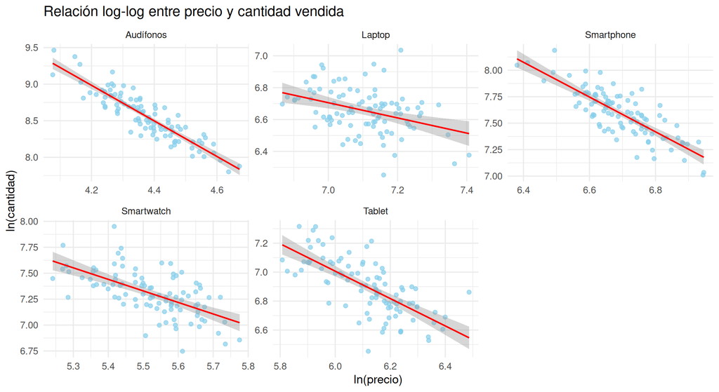

```r
ggplot(ventas, aes(log(precio), log(cantidad))) +
  geom_point(color = "skyblue", alpha = 0.7) +
  geom_smooth(method = "lm", color = "red", linewidth = 0.8) +
  facet_wrap(~producto, scales = "free") +
  labs(
    title = "Relación log-log entre precio y cantidad vendida",
    x = "ln(precio)",
    y = "ln(cantidad)"
  )
```

## 1.2 Estimación de la elasticidad

Se especifica una regresión lineal con `parsnip` y se ajusta una vez por producto: `nest()` guarda los datos de cada producto en una lista y `map()` ajusta el modelo a cada uno. El coeficiente de $\ln(P)$ es la elasticidad.

```r
modelo_lm <- linear_reg() |>
  set_engine("lm")

ajustes_demanda <- ventas |>
  nest(datos = -producto) |>
  mutate(
    ajuste = map(datos, \(d) {
      fit(modelo_lm, log(cantidad) ~ log(precio), data = d)
    }),
    coeficientes = map(ajuste, \(m) tidy(m, conf.int = TRUE)),
    r2 = map_dbl(ajuste, \(m) glance(m)$r.squared)
  )

elasticidades <- ajustes_demanda |>
  unnest(coeficientes) |>
  filter(term == "log(precio)") |>
  select(producto, elasticidad = estimate, conf.low, conf.high, p.value, r2) |>
  arrange(producto)

elasticidades |> mutate(across(where(is.numeric), \(x) round(x, 3)))
```

| producto | elasticidad | conf.low | conf.high | p.value | r2 |
| --- | --- | --- | --- | --- | --- |
| Audífonos | -2.432 | -2.675 | -2.189 | 0 | 0.808 |
| Laptop | -0.477 | -0.715 | -0.238 | 0 | 0.143 |
| Smartphone | -1.643 | -1.890 | -1.396 | 0 | 0.650 |
| Smartwatch | -1.112 | -1.403 | -0.821 | 0 | 0.380 |
| Tablet | -0.946 | -1.142 | -0.750 | 0 | 0.493 |

Todas las elasticidades son negativas y significativas, como predice la **ley de la demanda**. Por ejemplo, para los audífonos un aumento del 1 % en el precio reduce la cantidad vendida en cerca de 2.4 %.

## 1.3 Del modelo a la decisión de precios

Como el ingreso es $I = P \cdot Q$ y $Q \propto P^{E_p}$, el ingreso varía según $P^{1 + E_p}$:

- **Demanda elástica** ($E_p < -1$): bajar el precio **aumenta** el ingreso.
- **Demanda inelástica** ($-1 < E_p < 0$): subir el precio **aumenta** el ingreso.

```r
elasticidades |>
  transmute(
    producto,
    elasticidad = round(elasticidad, 2),
    tipo = if_else(elasticidad < -1, "Elástica", "Inelástica"),
    `Δ% ingreso si el precio sube 5 %` = round(
      (1.05^(1 + elasticidad) - 1) * 100,
      1
    ),
    `Δ% ingreso si el precio baja 5 %` = round(
      (0.95^(1 + elasticidad) - 1) * 100,
      1
    ),
    recomendacion = if_else(elasticidad < -1, "Bajar precio", "Subir precio")
  )
```

| producto | elasticidad | tipo | Δ% ingreso si el precio sube 5 % | Δ% ingreso si el precio baja 5 % | recomendacion |
| --- | --- | --- | --- | --- | --- |
| Audífonos | -2.43 | Elástica | -6.7 | 7.6 | Bajar precio |
| Laptop | -0.48 | Inelástica | 2.6 | -2.6 | Subir precio |
| Smartphone | -1.64 | Elástica | -3.1 | 3.3 | Bajar precio |
| Smartwatch | -1.11 | Elástica | -0.5 | 0.6 | Bajar precio |
| Tablet | -0.95 | Inelástica | 0.2 | -0.3 | Subir precio |

Antes de decidir conviene mirar los intervalos de confianza: para Smartwatch y Tablet el intervalo incluye $E_p = -1$, por lo que no se puede afirmar si la demanda es elástica o inelástica y el efecto de un cambio de precio sobre el ingreso es pequeño e incierto.

## 1.4 Pronóstico con el modelo

Con `predict()` se pronostica la cantidad para un precio nuevo. Por ejemplo, el efecto de bajar 5 % el precio de los audífonos respecto a su precio promedio:

```r
ajuste_audifonos <- ajustes_demanda |>
  filter(producto == "Audífonos") |>
  pull(ajuste) |>
  pluck(1)

precio_medio <- mean(ventas$precio[ventas$producto == "Audífonos"])

escenarios <- tibble(
  escenario = c("Precio promedio", "Precio -5 %"),
  precio = precio_medio * c(1, 0.95)
)

escenarios |>
  bind_cols(predict(ajuste_audifonos, new_data = escenarios)) |>
  mutate(
    cantidad = exp(.pred),
    ingreso = precio * cantidad,
    across(where(is.numeric), \(x) round(x, 1))
  ) |>
  select(-.pred)
```

| escenario | precio | cantidad | ingreso |
| --- | --- | --- | --- |
| Precio promedio | 79.8 | 5149.6 | 411047.1 |
| Precio -5 % | 75.8 | 5833.8 | 442380.5 |

# 2 Caso 2. Fuga de clientes (churn)

Una empresa de telecomunicaciones quiere decidir **a qué clientes dirigir una campaña de retención**. Se comparan tres modelos de clasificación: logit, árbol de clasificación y random forest.

## 2.1 Datos

```r
telco <- read_csv("datos/telco_churn.csv", show_col_types = FALSE) |>
  mutate(
    # Mensual como categoría de referencia
    contrato = factor(contrato, levels = c("Mensual", "Anual", "Bianual")),
    churn = factor(churn, levels = 0:1, labels = c("Permanece", "Fuga"))
  )

head(telco)
```

| id_cliente | antiguedad | cargo_mensual | contrato | llamadas_soporte | pago_electronico | churn | conjunto |
| --- | --- | --- | --- | --- | --- | --- | --- |
| 1 | 38 | 52.2 | Bianual | 1 | 0 | Permanece | entrenamiento |
| 2 | 45 | 119.3 | Anual | 2 | 0 | Permanece | entrenamiento |
| 3 | 36 | 98.6 | Mensual | 1 | 1 | Fuga | entrenamiento |
| 4 | 48 | 59.7 | Bianual | 3 | 0 | Permanece | entrenamiento |
| 5 | 5 | 50.0 | Anual | 3 | 0 | Permanece | entrenamiento |
| 6 | 31 | 88.0 | Anual | 0 | 0 | Permanece | entrenamiento |

```r
telco |>
  group_by(contrato) |>
  summarise(clientes = n(), tasa_fuga = round(mean(churn == "Fuga") * 100, 1))
```

| contrato | clientes | tasa_fuga |
| --- | --- | --- |
| Mensual | 2706 | 29.0 |
| Anual | 1261 | 14.0 |
| Bianual | 1033 | 7.9 |

La tasa de fuga general es de 20.8 %. Los clientes con contrato mensual se van mucho más que los de contratos largos.

## 2.2 Entrenamiento y prueba

Partición estratificada: 70 % para entrenar y 30 % para evaluar, con la misma proporción de fuga en ambos conjuntos. Con `rsample` se haría así:

```r
set.seed(2026)
particion <- initial_split(telco, prop = 0.7, strata = churn)
```

Para que los resultados coincidan con la versión en Python, la partición ya viene definida en la columna `conjunto` de los datos. `make_splits()` construye con ella el mismo tipo de objeto que devuelve `initial_split()`:

```r
particion <- make_splits(
  list(
    analysis = which(telco$conjunto == "entrenamiento"),
    assessment = which(telco$conjunto == "prueba")
  ),
  data = telco
)
particion
```

```
<Analysis/Assess/Total>
<3500/1500/5000>
```

```r
entrenamiento <- training(particion)
prueba <- testing(particion)

bind_rows(Entrenamiento = entrenamiento, Prueba = prueba, .id = "conjunto") |>
  group_by(conjunto) |>
  summarise(clientes = n(), tasa_fuga = round(mean(churn == "Fuga") * 100, 1))
```

| conjunto | clientes | tasa_fuga |
| --- | --- | --- |
| Entrenamiento | 3500 | 20.8 |
| Prueba | 1500 | 20.9 |

## 2.3 Receta de preprocesamiento

La receta declara que `churn` es la variable de respuesta y que `id_cliente` y `conjunto` son identificadores, no predictores. Se usa la misma receta para los tres modelos.

```r
receta <- recipe(churn ~ ., data = entrenamiento) |>
  update_role(id_cliente, conjunto, new_role = "id")

summary(receta)
```

| variable | type | role | source |
| --- | --- | --- | --- |
| id_cliente | double , numeric | id | original |
| antiguedad | double , numeric | predictor | original |
| cargo_mensual | double , numeric | predictor | original |
| contrato | factor , unordered, nominal | predictor | original |
| llamadas_soporte | double , numeric | predictor | original |
| pago_electronico | double , numeric | predictor | original |
| conjunto | string , unordered, nominal | id | original |
| churn | factor , unordered, nominal | outcome | original |

## 2.4 Regresión logística (logit)

Cada modelo se especifica con `parsnip` (tipo de modelo + motor) y se une a la receta en un `workflow`, que se ajusta con los datos de entrenamiento.

```r
logit_fit <- workflow(
  preprocessor = receta,
  spec = logistic_reg() |> set_engine("glm")
) |>
  fit(data = entrenamiento)

tidy(logit_fit) |> mutate(across(where(is.numeric), \(x) round(x, 4)))
```

| term | estimate | std.error | statistic | p.value |
| --- | --- | --- | --- | --- |
| (Intercept) | -2.1555 | 0.1873 | -11.5111 | 0 |
| antiguedad | -0.0419 | 0.0025 | -16.5649 | 0 |
| cargo_mensual | 0.0231 | 0.0020 | 11.5351 | 0 |
| contratoAnual | -1.1734 | 0.1218 | -9.6321 | 0 |
| contratoBianual | -1.9224 | 0.1646 | -11.6795 | 0 |
| llamadas_soporte | 0.4632 | 0.0383 | 12.0841 | 0 |
| pago_electronico | 0.5355 | 0.0961 | 5.5725 | 0 |

Los **odds ratios** ($e^{\beta_j}$) facilitan la interpretación:

```r
odds_ratios <- tidy(logit_fit, exponentiate = TRUE, conf.int = TRUE) |>
  select(
    variable = term,
    odds_ratio = estimate,
    conf.low,
    conf.high,
    p.value
  )

odds_ratios |> mutate(across(where(is.numeric), \(x) round(x, 3)))
```

| variable | odds_ratio | conf.low | conf.high | p.value |
| --- | --- | --- | --- | --- |
| (Intercept) | 0.116 | 0.080 | 0.167 | 0 |
| antiguedad | 0.959 | 0.954 | 0.964 | 0 |
| cargo_mensual | 1.023 | 1.019 | 1.027 | 0 |
| contratoAnual | 0.309 | 0.243 | 0.391 | 0 |
| contratoBianual | 0.146 | 0.105 | 0.200 | 0 |
| llamadas_soporte | 1.589 | 1.475 | 1.714 | 0 |
| pago_electronico | 1.708 | 1.415 | 2.063 | 0 |

Cada llamada adicional a soporte multiplica los *odds* de fuga por 1.59, mientras que un contrato bianual los multiplica por 0.15 frente al contrato mensual.

## 2.5 Árbol de clasificación

Se limita la profundidad a 3 niveles (`tree_depth`) y se exigen al menos 50 clientes por hoja (`minbucket`, argumento del motor `rpart`) para evitar el sobreajuste.

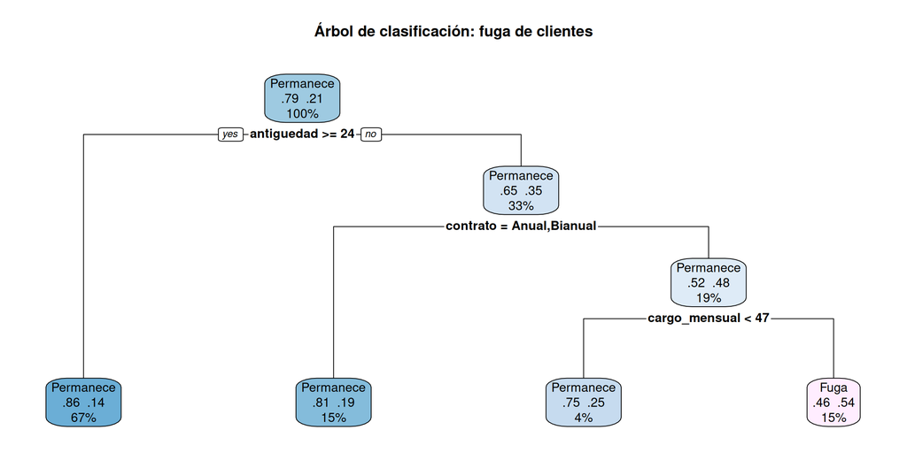

```r
arbol_spec <- decision_tree(tree_depth = 3, min_n = 150, cost_complexity = 0) |>
  set_engine("rpart", minbucket = 50) |>
  set_mode("classification")

arbol_fit <- workflow(receta, arbol_spec) |>
  fit(data = entrenamiento)

arbol_rpart <- extract_fit_engine(arbol_fit)

rpart.plot(
  arbol_rpart,
  type = 2,
  extra = 104,
  box.palette = "BuPu",
  roundint = FALSE,
  main = "Árbol de clasificación: fuga de clientes"
)
```

El árbol puede expresarse como **reglas de decisión** para comunicarlas a la gerencia:

```r
reglas <- rpart.rules(arbol_rpart, cover = TRUE, roundint = FALSE)
names(reglas)[1] <- "prob_fuga" # workflows llama `..y` a la variable de respuesta
reglas
```

|  | prob_fuga |  |  |  |  |  |  |  |  |  |  |  |  | cover |
| --- | --- | --- | --- | --- | --- | --- | --- | --- | --- | --- | --- | --- | --- | --- |
| 2 | 0.14 | when | antiguedad | >= | 24 |  |  |  |  |  |  |  |  | 67% |
| 6 | 0.19 | when | antiguedad | < | 24 | & | contrato | is | Anual or Bianual |  |  |  |  | 15% |
| 14 | 0.25 | when | antiguedad | < | 24 | & | contrato | is | Mensual | & | cargo_mensual | < | 47 | 4% |
| 15 | 0.54 | when | antiguedad | < | 24 | & | contrato | is | Mensual | & | cargo_mensual | >= | 47 | 15% |

## 2.6 Random forest

Se usa el motor `randomForest`. El cambio de motor (por ejemplo a `ranger`, el más usado en tidymodels) solo requiere modificar `set_engine()`.

```r
bosque_spec <- rand_forest(trees = 300, min_n = 20) |>
  set_engine("randomForest") |>
  set_mode("classification")

set.seed(2026)
bosque_fit <- workflow(receta, bosque_spec) |>
  fit(data = entrenamiento)

bosque_fit
```

```
══ Workflow [trained] ══════════════════════════════════════════════════════════
Preprocessor: Recipe
Model: rand_forest()

── Preprocessor ────────────────────────────────────────────────────────────────
0 Recipe Steps

── Model ───────────────────────────────────────────────────────────────────────

Call:
 randomForest(x = maybe_data_frame(x), y = y, ntree = 300, nodesize = min_rows(~20,      x))
               Type of random forest: classification
                     Number of trees: 300
No. of variables tried at each split: 2

        OOB estimate of  error rate: 17.8%
Confusion matrix:
          Permanece Fuga class.error
Permanece      2659  112  0.04041862
Fuga            511  218  0.70096022
```

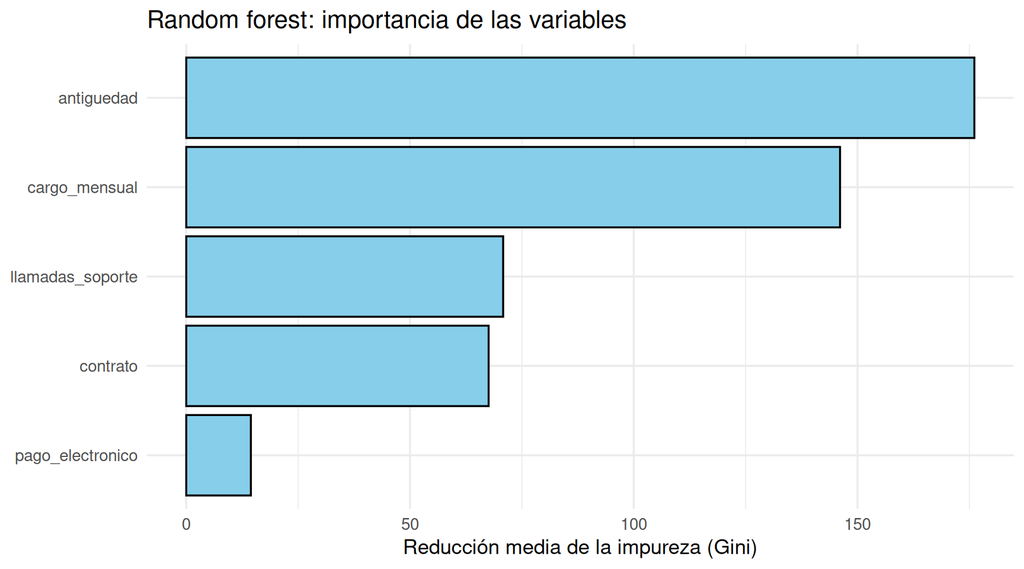

```r
extract_fit_engine(bosque_fit)$importance |>
  as_tibble(rownames = "variable") |>
  ggplot(aes(MeanDecreaseGini, reorder(variable, MeanDecreaseGini))) +
  geom_col(fill = "skyblue", color = "black") +
  labs(
    title = "Random forest: importancia de las variables",
    x = "Reducción media de la impureza (Gini)",
    y = NULL
  )
```

## 2.7 Comparación de modelos

`augment()` agrega al conjunto de prueba la clase predicha (`.pred_class`, con umbral 0.5) y las probabilidades de cada clase (`.pred_Permanece`, `.pred_Fuga`). Con `yardstick` se calculan las métricas; como `Fuga` es el segundo nivel de `churn`, se indica `event_level = "second"`.

```r
modelos <- list(
  "Logit" = logit_fit,
  "Árbol" = arbol_fit,
  "Random forest" = bosque_fit
)

predicciones <- modelos |>
  map(\(m) augment(m, new_data = prueba)) |>
  list_rbind(names_to = "Modelo") |>
  mutate(Modelo = factor(Modelo, levels = names(modelos)))

metricas_clasificacion <- metric_set(
  accuracy,
  precision,
  sensitivity,
  specificity,
  f_meas,
  roc_auc
)

metricas <- predicciones |>
  group_by(Modelo) |>
  metricas_clasificacion(
    truth = churn,
    estimate = .pred_class,
    .pred_Fuga,
    event_level = "second"
  ) |>
  mutate(
    .metric = recode(
      .metric,
      accuracy = "Exactitud",
      precision = "Precisión",
      sensitivity = "Sensibilidad",
      specificity = "Especificidad",
      f_meas = "F1",
      roc_auc = "AUC"
    )
  ) |>
  pivot_wider(id_cols = Modelo, names_from = .metric, values_from = .estimate)

mejor_modelo <- as.character(metricas$Modelo[which.max(metricas$AUC)])

metricas |> mutate(across(where(is.numeric), \(x) round(x, 3)))
```

| Modelo | Exactitud | Precisión | Sensibilidad | Especificidad | F1 | AUC |
| --- | --- | --- | --- | --- | --- | --- |
| Logit | 0.813 | 0.601 | 0.304 | 0.947 | 0.403 | 0.803 |
| Árbol | 0.792 | 0.502 | 0.348 | 0.909 | 0.411 | 0.667 |
| Random forest | 0.819 | 0.650 | 0.291 | 0.959 | 0.402 | 0.785 |

El modelo con mayor AUC es **Logit**. Un modelo más complejo no siempre predice mejor: cuando la relación entre las variables y el *log-odds* de fuga es casi lineal, el logit compite de igual a igual con el random forest. Con el umbral de 0.5 la **sensibilidad es baja** (se detecta una minoría de los clientes que se van), lo que motiva revisar el umbral.

## 2.8 Matriz de confusión y curva ROC

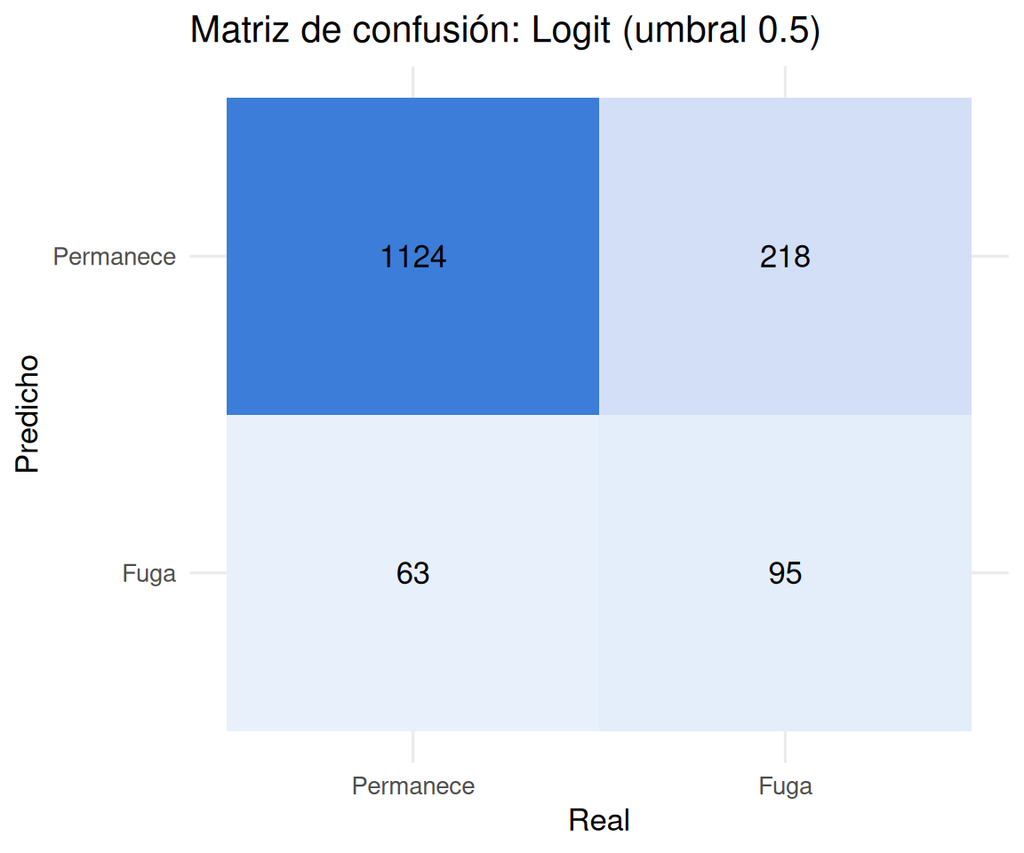

```r
predicciones |>
  filter(Modelo == mejor_modelo) |>
  conf_mat(truth = churn, estimate = .pred_class) |>
  autoplot(type = "heatmap") +
  scale_fill_gradient(low = "#e8f1fb", high = "#3b7dd8") +
  labs(
    title = paste("Matriz de confusión:", mejor_modelo, "(umbral 0.5)"),
    x = "Real",
    y = "Predicho"
  )
```

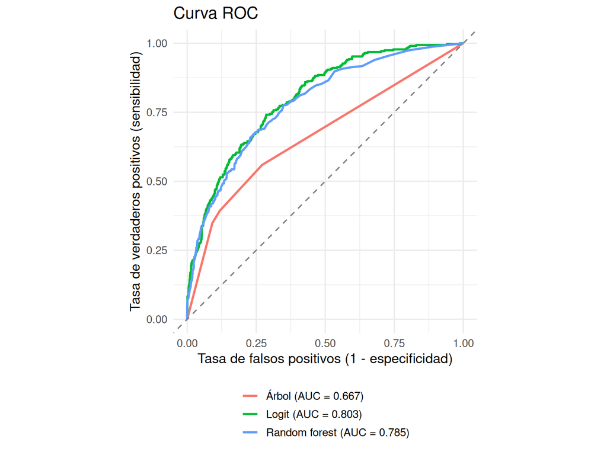

```r
etiquetas_auc <- metricas |>
  transmute(Modelo, etiqueta = sprintf("%s (AUC = %.3f)", Modelo, AUC))

predicciones |>
  group_by(Modelo) |>
  roc_curve(truth = churn, .pred_Fuga, event_level = "second") |>
  left_join(etiquetas_auc, by = "Modelo") |>
  ggplot(aes(1 - specificity, sensitivity, color = etiqueta)) +
  geom_path(linewidth = 1) +
  geom_abline(linetype = "dashed", color = "gray50") +
  coord_equal() +
  labs(
    title = "Curva ROC",
    x = "Tasa de falsos positivos (1 - especificidad)",
    y = "Tasa de verdaderos positivos (sensibilidad)",
    color = NULL
  ) +
  theme(legend.position = "bottom", legend.direction = "vertical")
```

## 2.9 Elegir el umbral

Supuestos de la campaña: contactar a un cliente cuesta **USD 20** y retener a un cliente que se iba a fugar vale **USD 100**.

$$\text{Beneficio}(u) = 100 \cdot VP(u) - 20 \cdot \left[VP(u) + FP(u)\right]$$

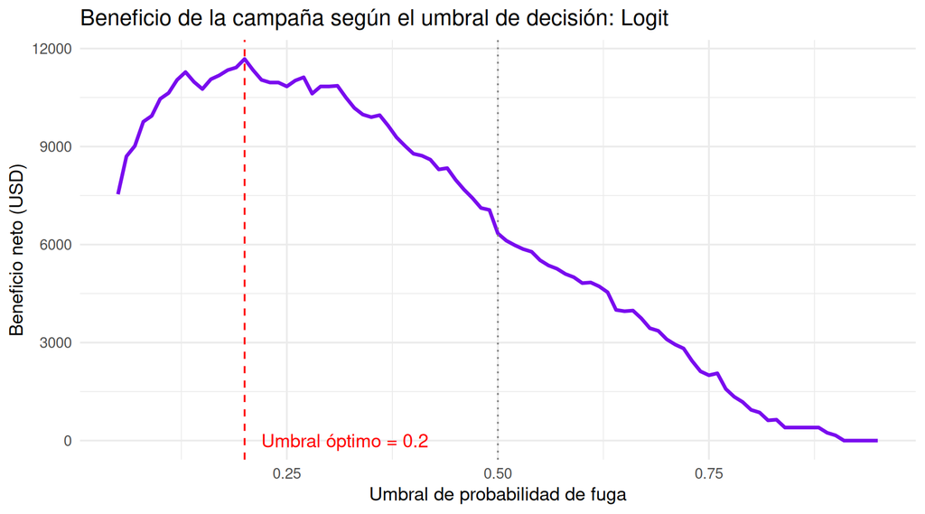

```r
pred_mejor <- filter(predicciones, Modelo == mejor_modelo)

beneficio <- tibble(umbral = seq(0.05, 0.95, by = 0.01)) |>
  mutate(
    contactados = map_dbl(umbral, \(u) sum(pred_mejor$.pred_Fuga >= u)),
    vp = map_dbl(umbral, \(u) {
      sum(pred_mejor$.pred_Fuga >= u & pred_mejor$churn == "Fuga")
    }),
    beneficio = 100 * vp - 20 * contactados
  )

optimo <- slice_max(beneficio, beneficio, n = 1, with_ties = FALSE)
beneficio_05 <- beneficio$beneficio[near(beneficio$umbral, 0.5)]

ggplot(beneficio, aes(umbral, beneficio)) +
  geom_line(color = "#790cee", linewidth = 1.2) +
  geom_vline(xintercept = optimo$umbral, color = "red", linetype = "dashed") +
  geom_vline(xintercept = 0.5, color = "gray50", linetype = "dotted") +
  annotate(
    "text",
    x = optimo$umbral,
    y = min(beneficio$beneficio),
    hjust = -0.1,
    label = paste("Umbral óptimo =", optimo$umbral),
    color = "red"
  ) +
  labs(
    title = paste(
      "Beneficio de la campaña según el umbral de decisión:",
      mejor_modelo
    ),
    x = "Umbral de probabilidad de fuga",
    y = "Beneficio neto (USD)"
  )
```

Con el umbral por defecto de 0.5 la campaña genera USD 6.340. Con el umbral óptimo de 0.2 se contacta a 576 clientes y el beneficio sube a USD 11.680. Como retener a un cliente vale cinco veces lo que cuesta contactarlo, conviene contactar a muchos más clientes de los que el umbral de 0.5 sugiere.

Con el umbral óptimo, las métricas del modelo cambian: se sacrifica precisión a cambio de detectar a muchos más clientes que se van.

```r
pred_mejor |>
  mutate(
    .pred_class = factor(
      if_else(.pred_Fuga >= optimo$umbral, "Fuga", "Permanece"),
      levels = levels(churn)
    )
  ) |>
  metric_set(accuracy, precision, sensitivity, specificity)(
    truth = churn,
    estimate = .pred_class,
    event_level = "second"
  ) |>
  transmute(
    metrica = recode(
      .metric,
      accuracy = "Exactitud",
      precision = "Precisión",
      sensitivity = "Sensibilidad",
      specificity = "Especificidad"
    ),
    `umbral 0.5` = map_dbl(metrica, \(m) {
      metricas[[m]][metricas$Modelo == mejor_modelo]
    }),
    `umbral óptimo` = .estimate
  ) |>
  mutate(across(where(is.numeric), \(x) round(x, 3)))
```

| metrica | umbral 0.5 | umbral óptimo |
| --- | --- | --- |
| Exactitud | 0.813 | 0.717 |
| Precisión | 0.601 | 0.403 |
| Sensibilidad | 0.304 | 0.741 |
| Especificidad | 0.947 | 0.710 |

# 3 Caso 3. Segmentación de clientes (RFM)

El área de marketing de una cadena de retail quiere diseñar acciones diferenciadas según el comportamiento de compra de sus clientes: **recencia**, **frecuencia** y **ticket promedio**.

## 3.1 Datos

```r
retail <- read_csv("datos/retail_rfm.csv", show_col_types = FALSE)
summary(select(retail, -id_cliente))
```

```
    recencia        frecuencia    ticket_promedio
 Min.   :  1.00   Min.   : 1.00   Min.   : 13.30
 1st Qu.: 27.00   1st Qu.: 3.00   1st Qu.: 44.48
 Median : 50.00   Median : 8.00   Median : 62.30
 Mean   : 94.19   Mean   :10.23   Mean   : 87.86
 3rd Qu.:150.00   3rd Qu.:15.00   3rd Qu.:127.20
 Max.   :365.00   Max.   :40.00   Max.   :293.30
```

## 3.2 Estandarización con una receta

k-means usa distancias, así que las variables se estandarizan con `step_normalize()`. Al preparar la receta (`prep()`) se guardan la media y la desviación de cada variable, que después se reutilizan para estandarizar clientes nuevos.

```r
variables_rfm <- c("recencia", "frecuencia", "ticket_promedio")

receta_rfm <- recipe(
  ~ recencia + frecuencia + ticket_promedio,
  data = retail
) |>
  step_normalize(all_numeric_predictors()) |>
  prep()

X_rfm <- bake(receta_rfm, new_data = NULL)

tidy(receta_rfm, number = 1) |> select(variable = terms, statistic, value)
```

| variable | statistic | value |
| --- | --- | --- |
| recencia | mean | 94.188500 |
| frecuencia | mean | 10.231000 |
| ticket_promedio | mean | 87.859050 |
| recencia | sd | 94.926822 |
| frecuencia | sd | 8.086305 |
| ticket_promedio | sd | 58.125537 |

## 3.3 Elegir el número de grupos

Se estima k-means para $k = 2, \dots, 8$, con 10 inicializaciones aleatorias cada uno (`nstart`). `glance()` entrega la inercia (`tot.withinss`) de cada modelo.

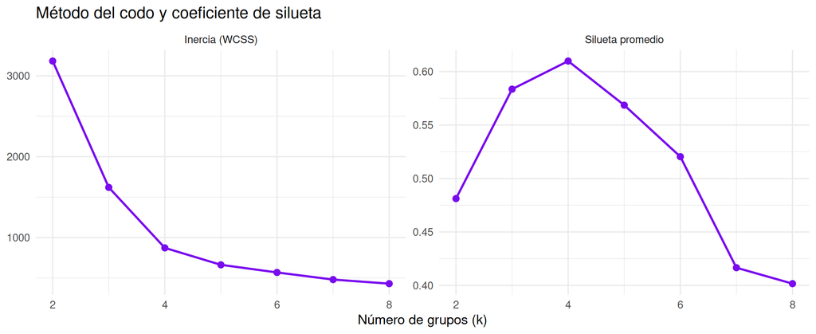

```r
distancias <- dist(X_rfm)

set.seed(2026)
seleccion_k <- tibble(k = 2:8) |>
  mutate(
    modelo = map(k, \(k) kmeans(X_rfm, centers = k, nstart = 10)),
    `Inercia (WCSS)` = map_dbl(modelo, \(m) glance(m)$tot.withinss),
    `Silueta promedio` = map_dbl(modelo, \(m) {
      mean(silhouette(m$cluster, distancias)[, "sil_width"])
    })
  )

seleccion_k |>
  select(-modelo) |>
  pivot_longer(-k, names_to = "criterio", values_to = "valor") |>
  ggplot(aes(k, valor)) +
  geom_line(color = "#790cee", linewidth = 1) +
  geom_point(color = "#790cee", size = 2.5) +
  facet_wrap(~criterio, scales = "free_y") +
  labs(
    title = "Método del codo y coeficiente de silueta",
    x = "Número de grupos (k)",
    y = NULL
  )
```

El codo aparece en $k = 4$, que también maximiza la silueta.

## 3.4 Estimación y perfil de los segmentos

`augment()` agrega a los datos la columna `.cluster` con el grupo asignado a cada cliente.

```r
set.seed(2026)
kmeans_rfm <- kmeans(X_rfm, centers = 4, nstart = 10)

# Nombrar los segmentos ordenándolos por recencia (de más a menos reciente)
nombres <- c("Campeones", "Leales", "Ocasionales de alto ticket", "Inactivos")

retail <- augment(kmeans_rfm, retail) |>
  rename(grupo = .cluster)

perfil <- retail |>
  group_by(grupo) |>
  summarise(across(all_of(variables_rfm), mean), clientes = n()) |>
  mutate(pct_clientes = clientes / sum(clientes) * 100) |>
  arrange(recencia) |>
  mutate(segmento = factor(nombres, levels = nombres))

retail <- left_join(retail, select(perfil, grupo, segmento), by = "grupo")

perfil |>
  select(segmento, all_of(variables_rfm), clientes, pct_clientes) |>
  mutate(across(where(is.numeric), \(x) round(x, 1)))
```

| segmento | recencia | frecuencia | ticket_promedio | clientes | pct_clientes |
| --- | --- | --- | --- | --- | --- |
| Campeones | 10.6 | 25.2 | 121.4 | 295 | 14.8 |
| Leales | 36.3 | 12.6 | 60.1 | 745 | 37.2 |
| Ocasionales de alto ticket | 71.7 | 5.2 | 184.7 | 393 | 19.7 |
| Inactivos | 229.3 | 2.9 | 39.7 | 567 | 28.3 |

## 3.5 Visualización de los segmentos

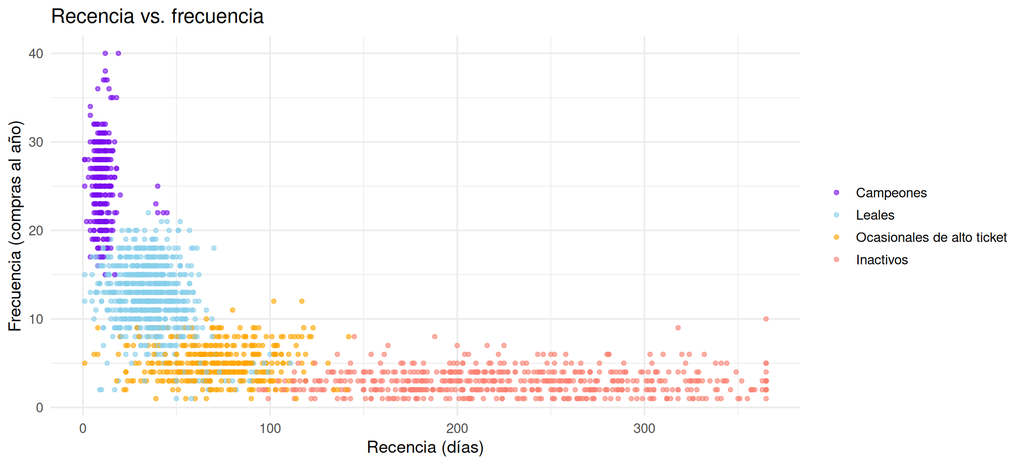

```r
colores <- c("#790cee", "skyblue", "orange", "salmon")

ggplot(retail, aes(recencia, frecuencia, color = segmento)) +
  geom_point(size = 1.2, alpha = 0.6) +
  scale_color_manual(values = colores) +
  labs(
    title = "Recencia vs. frecuencia",
    x = "Recencia (días)",
    y = "Frecuencia (compras al año)",
    color = NULL
  )
```

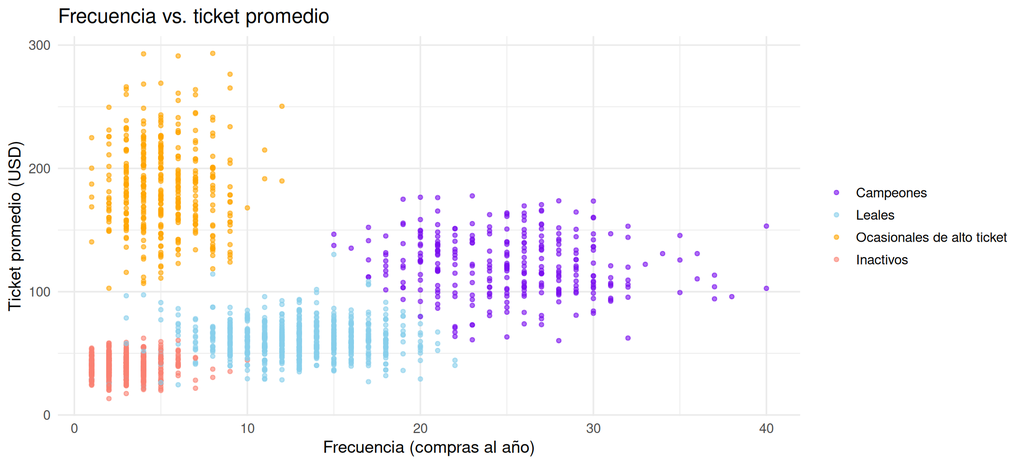

```r
ggplot(retail, aes(frecuencia, ticket_promedio, color = segmento)) +
  geom_point(size = 1.2, alpha = 0.6) +
  scale_color_manual(values = colores) +
  labs(
    title = "Frecuencia vs. ticket promedio",
    x = "Frecuencia (compras al año)",
    y = "Ticket promedio (USD)",
    color = NULL
  )
```

## 3.6 Asignar un cliente nuevo

Un cliente nuevo se estandariza con la **misma receta** (`bake()` usa la media y la desviación de los datos originales) y se asigna al **centroide más cercano**. Los centroides se obtienen con `tidy()`.

```r
nuevo <- tibble(recencia = 15, frecuencia = 20, ticket_promedio = 110)
nuevo_z <- bake(receta_rfm, new_data = nuevo)

tidy(kmeans_rfm) |>
  mutate(
    distancia = sqrt(
      (recencia - nuevo_z$recencia)^2 +
        (frecuencia - nuevo_z$frecuencia)^2 +
        (ticket_promedio - nuevo_z$ticket_promedio)^2
    )
  ) |>
  slice_min(distancia, n = 1) |>
  left_join(select(perfil, grupo, segmento), by = c("cluster" = "grupo")) |>
  transmute(segmento, distancia = round(distancia, 3))
```

| segmento | distancia |
| --- | --- |
| Campeones | 0.678 |

## 3.7 Acciones por segmento

| Segmento | Acción comercial sugerida |
| --- | --- |
| **Campeones** | Programa de fidelización, acceso anticipado a lanzamientos, embajadores de marca |
| **Leales** | Venta cruzada y venta adicional para subir el ticket |
| **Ocasionales de alto ticket** | Recordatorios personalizados y beneficios por recompra para aumentar la frecuencia |
| **Inactivos** | Campaña de reactivación de bajo costo; si no responden, reducir inversión |